# Source code for: Relations among Phonological Processing Skills and Mathematics in Children: A Meta-analysis

Jason Lo

2021-01-08

```r
source("helper_functions.R")
library(tidyverse)
library(corrr)
library(metaSEM)
mxOption(NULL, 'Number of Threads', parallel::detectCores() - 2)
df <- csv_to_meta_df("main_data_201224.csv", "correlation_data_210108.csv")
```

# Two-stage meta SEM

- Due to large amount of missing data in the raw correlation matrix, we opted to use two-stage meta-analytic structural equation modeling for the analysis. In the first stage, we use a multivariate approach to combine correlation matrices across all studies. In the second stage, we fit a structural equation model with the pooled correlation (See Cheung & Chan, 2005; Cheung & Hafdahl, 2016 for further details).

*References:* Cheung, M. W. L., & Chan, W. (2005). Meta-analytic structural equation modeling: A two-stage approach. Psychological Methods, 10(1), 40–64. https://doi.org/10.1037/1082-989X.10.1.40

Cheung, M. W. L., & Hafdahl, A. R. (2016). Special issue on meta-analytic structural equation modeling: introduction from the guest editors. Research Synthesis Methods, 7(2), 112–120. https://doi.org/10.1002/jrsm.1212

## Two latent models

- Phonological skill (pho): a latent variable that is measured by pa, ran, and pm
- Cognitive skill (cog): a latent variable that is measured by nviq, vocab, and ef

### Number knowledge

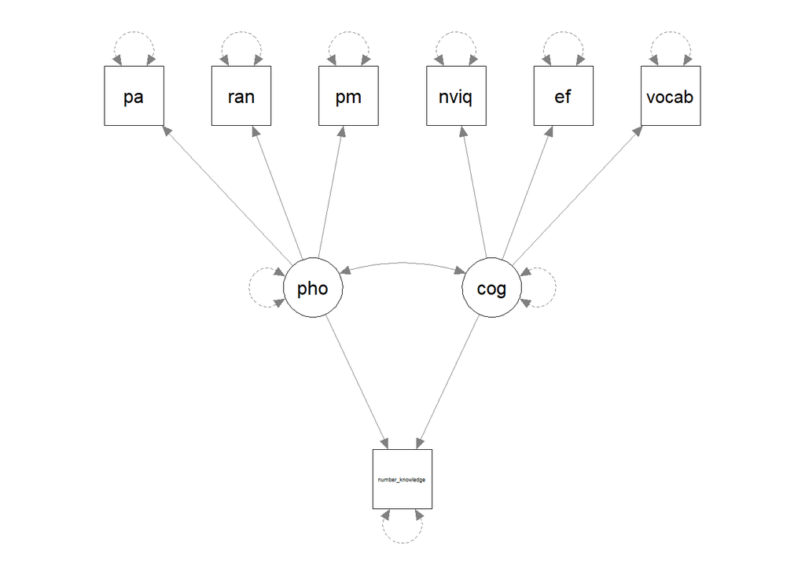

```r
observed_variables <- c('pa', 'ran', 'pm', 'nviq', 'vocab', 'ef', 'number_knowledge')

# Since not all variable will be used from the raw data, we have to call prep_input
# to create a trimmed data set
data <- prep_input(df, observed_variables)

lavaan_spec <- 'pho =~ pa + ran + pm
                cog =~ nviq + ef + vocab
                cog ~~ pho
                number_knowledge ~ cog + pho'

plot(lavaan_spec)
```

```r
RAM_spec <- lavaan2RAM(lavaan_spec, obs.variables=observed_variables)

stage1 <-tssem1(data$cor, data$n, method="REM") %>%
      rerun(autofixtau2 = TRUE)
```

```
## Running TSSEM1 Correlation with 42 parameters
```

```
##
## Beginning initial fit attempt
```

```
## Running TSSEM1 Correlation with 42 parameters
```

```
##
##  Lowest minimum so far:  -499.566656009033
```

```
##  OpenMx status code 6 not in list of acceptable status codes, (0,1)
```

```
##
## Beginning fit attempt 1 of at maximum 10 extra tries
```

```
## Running TSSEM1 Correlation with 42 parameters
```

```
##
##  Lowest minimum so far:  -499.566656022394
```

```
##
## Solution found
```

```
##
##  Solution found!  Final fit=-499.56666 (started at -499.56666)  (2 attempt(s): 2 valid, 0 errors)
```

```
## Running TSSEM1 Correlation with 42 parameters
```

```
##
## Beginning initial fit attempt
```

```
## Running TSSEM1 Correlation with 42 parameters
```

```
##
##  Lowest minimum so far:  -499.566656037383
```

```
##
## Solution found
```

```
##
##  Solution found!  Final fit=-499.56666 (started at -499.56666)  (1 attempt(s): 1 valid, 0 errors)
```

```r
stage2 <- tssem2(stage1, RAM=RAM_spec, intervals.type="z") %>%
  rerun()
```

```
## Running TSSEM2 Correlation with 9 parameters
```

```
##
## Beginning initial fit attempt
```

```
## Running TSSEM2 Correlation with 9 parameters
```

```
##
##  Lowest minimum so far:  20.0174461871254
```

```
##
## Solution found
```

```
##
##  Solution found!  Final fit=20.017446 (started at 20.017446)  (1 attempt(s): 1 valid, 0 errors)
```

```r
summary(stage2)
```

```
##
## Call:
## wls(Cov = pooledS, aCov = aCov, n = tssem1.obj$total.n, RAM = RAM,
##     Amatrix = Amatrix, Smatrix = Smatrix, Fmatrix = Fmatrix,
##     diag.constraints = diag.constraints, cor.analysis = cor.analysis,
##     intervals.type = intervals.type, mx.algebras = mx.algebras,
##     model.name = model.name, suppressWarnings = suppressWarnings,
##     silent = silent, run = run)
##
## 95% confidence intervals: z statistic approximation
## Coefficients:
##                        Estimate Std.Error    lbound    ubound z value Pr(>|z|)
## efONcog                0.589135  0.033430  0.523614  0.654656 17.6231  < 2e-16
## number_knowledgeONcog  0.056330  0.261101 -0.455419  0.568079  0.2157  0.82919
## number_knowledgeONpho  0.502710  0.251309  0.010153  0.995266  2.0004  0.04546
## nviqONcog              0.493905  0.023534  0.447779  0.540030 20.9868  < 2e-16
## paONpho                0.698941  0.026359  0.647278  0.750603 26.5163  < 2e-16
## pmONpho                0.514493  0.023776  0.467892  0.561093 21.6389  < 2e-16
## ranONpho               0.453407  0.022917  0.408491  0.498323 19.7848  < 2e-16
## vocabONcog             0.619103  0.029551  0.561184  0.677023 20.9502  < 2e-16
## phoWITHcog             0.902321  0.045782  0.812590  0.992053 19.7089  < 2e-16
##
## efONcog               ***
## number_knowledgeONcog
## number_knowledgeONpho *
## nviqONcog             ***
## paONpho               ***
## pmONpho               ***
## ranONpho              ***
## vocabONcog            ***
## phoWITHcog            ***
## ---
## Signif. codes:  0 '***' 0.001 '**' 0.01 '*' 0.05 '.' 0.1 ' ' 1
##
## Goodness-of-fit indices:
##                                                 Value
## Sample size                                16434.0000
## Chi-square of target model                    20.0174
## DF of target model                            12.0000
## p value of target model                        0.0668
## Number of constraints imposed on "Smatrix"     0.0000
## DF manually adjusted                           0.0000
## Chi-square of independence model            1977.8875
## DF of independence model                      21.0000
## RMSEA                                          0.0064
## RMSEA lower 95% CI                             0.0000
## RMSEA upper 95% CI                             0.0111
## SRMR                                           0.0325
## TLI                                            0.9928
## CFI                                            0.9959
## AIC                                           -3.9826
## BIC                                          -96.4678
## OpenMx status1: 0 ("0" or "1": The optimization is considered fine.
## Other values indicate problems.)
```

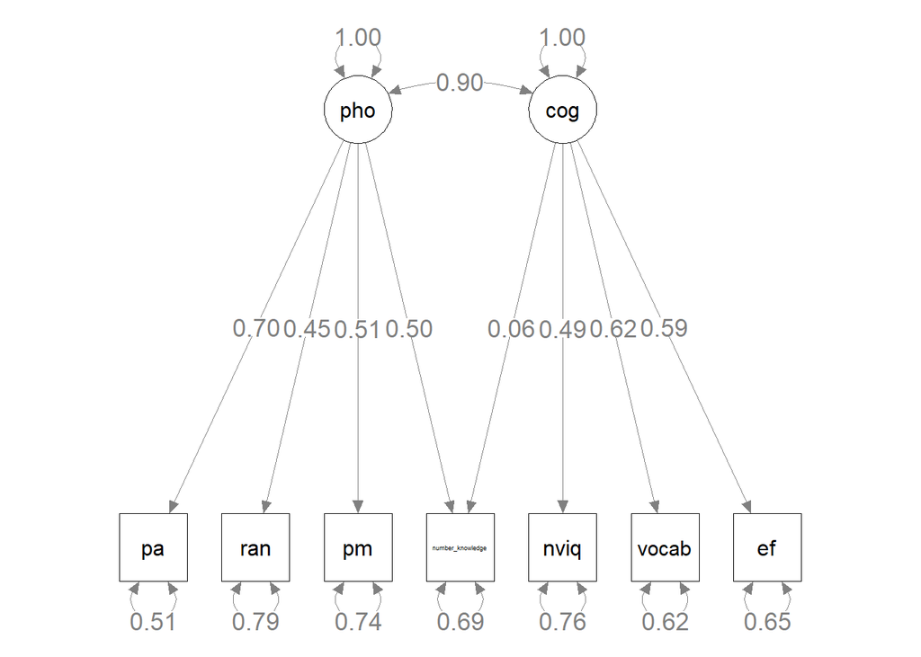

```r
plot(stage2)
```

Result summary: - Model fit statistic indicate a good fit, with Chi-square X2(12)=20.018, p=.07, CFI = .996, RMSEA =.006 - High correlation between pho and cog, r=.902, p<.001 (2e-16) - pho –> number_knowledge was significant, coef =.503, p<.05 - cog –> number_knowledge was not significant, coef =.056, p=.829

### Calculation

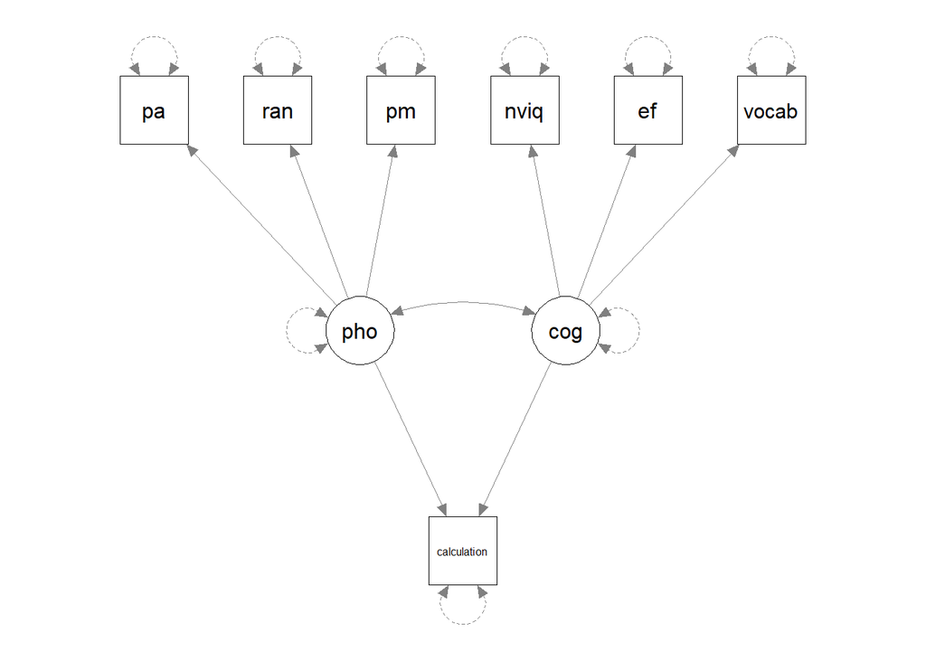

```r
observed_variables <- c('pa', 'ran', 'pm', 'nviq', 'vocab', 'ef', 'calculation')
data <- prep_input(df, observed_variables)
lavaan_spec <- 'pho =~ pa + ran + pm
                cog =~ nviq + ef + vocab
                cog ~~ pho
                calculation ~ cog + pho'

plot(lavaan_spec)
```

```r
RAM_spec <- lavaan2RAM(lavaan_spec, obs.variables=observed_variables)

stage1<-tssem1(data$cor, data$n, method="REM") %>%
      rerun(autofixtau2 = TRUE)
```

```
## Running TSSEM1 Correlation with 42 parameters
```

```
##
## Beginning initial fit attempt
```

```
## Running TSSEM1 Correlation with 42 parameters
```

```
##
##  Lowest minimum so far:  -492.937549890515
```

```
##
## Solution found
```

```
##
##  Solution found!  Final fit=-492.93755 (started at -492.93755)  (1 attempt(s): 1 valid, 0 errors)
```

```
## Running TSSEM1 Correlation with 42 parameters
```

```
##
## Beginning initial fit attempt
```

```
## Running TSSEM1 Correlation with 42 parameters
```

```
##
##  Lowest minimum so far:  -492.937549890599
```

```
##
## Solution found
```

```
##
##  Solution found!  Final fit=-492.93755 (started at -492.93755)  (1 attempt(s): 1 valid, 0 errors)
```

```r
stage2 <- tssem2(stage1, RAM=RAM_spec, intervals.type="z") %>%
  rerun()
```

```
## Running TSSEM2 Correlation with 9 parameters
```

```
##
## Beginning initial fit attempt
```

```
## Running TSSEM2 Correlation with 9 parameters
```

```
##
##  Lowest minimum so far:  24.1375521764989
```

```
##
## Solution found
```

```
##
##  Solution found!  Final fit=24.137552 (started at 24.137552)  (1 attempt(s): 1 valid, 0 errors)
```

```r
summary(stage2)
```

```
##
## Call:
## wls(Cov = pooledS, aCov = aCov, n = tssem1.obj$total.n, RAM = RAM,
##     Amatrix = Amatrix, Smatrix = Smatrix, Fmatrix = Fmatrix,
##     diag.constraints = diag.constraints, cor.analysis = cor.analysis,
##     intervals.type = intervals.type, mx.algebras = mx.algebras,
##     model.name = model.name, suppressWarnings = suppressWarnings,
##     silent = silent, run = run)
##
## 95% confidence intervals: z statistic approximation
## Coefficients:
##                   Estimate Std.Error    lbound    ubound z value Pr(>|z|)
## calculationONcog  0.274513  0.234792 -0.185671  0.734697  1.1692   0.2423
## calculationONpho  0.348566  0.229446 -0.101140  0.798272  1.5192   0.1287
## efONcog           0.570211  0.032940  0.505651  0.634772 17.3108   <2e-16 ***
## nviqONcog         0.506936  0.023005  0.461847  0.552024 22.0361   <2e-16 ***
## paONpho           0.689252  0.025782  0.638720  0.739784 26.7338   <2e-16 ***
## pmONpho           0.508552  0.022896  0.463677  0.553427 22.2115   <2e-16 ***
## ranONpho          0.471776  0.023120  0.426462  0.517091 20.4055   <2e-16 ***
## vocabONcog        0.615158  0.028690  0.558927  0.671389 21.4415   <2e-16 ***
## phoWITHcog        0.902675  0.045603  0.813295  0.992055 19.7942   <2e-16 ***
## ---
## Signif. codes:  0 '***' 0.001 '**' 0.01 '*' 0.05 '.' 0.1 ' ' 1
##
## Goodness-of-fit indices:
##                                                 Value
## Sample size                                16589.0000
## Chi-square of target model                    24.1376
## DF of target model                            12.0000
## p value of target model                        0.0195
## Number of constraints imposed on "Smatrix"     0.0000
## DF manually adjusted                           0.0000
## Chi-square of independence model            2119.3266
## DF of independence model                      21.0000
## RMSEA                                          0.0078
## RMSEA lower 95% CI                             0.0030
## RMSEA upper 95% CI                             0.0123
## SRMR                                           0.0328
## TLI                                            0.9899
## CFI                                            0.9942
## AIC                                            0.1376
## BIC                                          -92.4604
## OpenMx status1: 0 ("0" or "1": The optimization is considered fine.
## Other values indicate problems.)
```

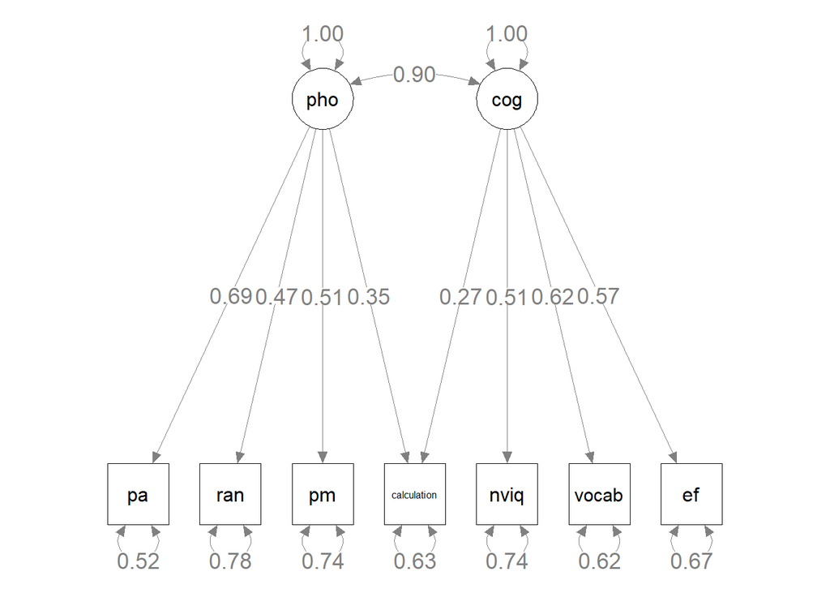

```r
plot(stage2)
```

Model fit statistic indicate a good fit, with Chi-square X2(12)=24.14, p=.02, CFI = .994, RMSEA =.008 High correlation between pho and cog, r=.90, p<.001 pho –> calculation was not significant, coef =.349, p=.129 cog –> calculation was not significant, coef =.275, p=.242

### Word problem

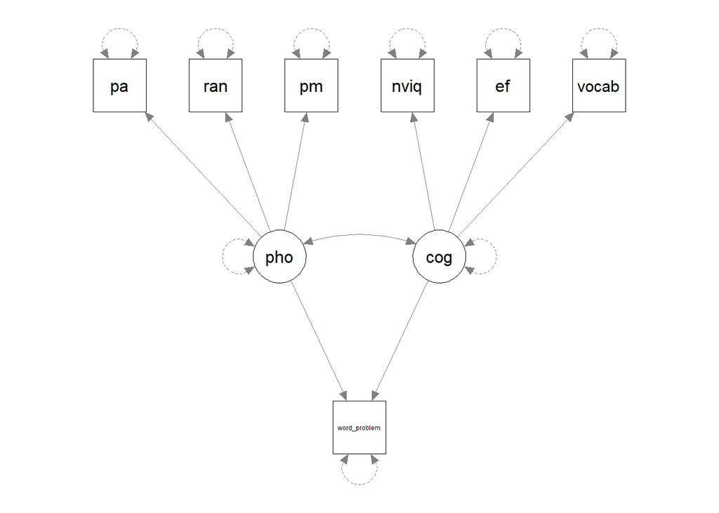

```r
observed_variables <- c('pa', 'ran', 'pm', 'nviq', 'vocab', 'ef', 'word_problem')
data <- prep_input(df, observed_variables)
lavaan_spec <- 'pho =~ pa + ran + pm
                cog =~ nviq + ef + vocab
                cog ~~ pho
                word_problem ~ cog + pho'

plot(lavaan_spec)
```

```r
RAM_spec <- lavaan2RAM(lavaan_spec, obs.variables=observed_variables)

stage1<-tssem1(data$cor, data$n, method="REM") %>%
      rerun(autofixtau2 = TRUE)
```

```
## Running TSSEM1 Correlation with 42 parameters
```

```
##
## Beginning initial fit attempt
```

```
## Running TSSEM1 Correlation with 42 parameters
```

```
##
##  Lowest minimum so far:  -387.349418742477
```

```
##
## Solution found
```

```
##
##  Solution found!  Final fit=-387.34942 (started at -387.34942)  (1 attempt(s): 1 valid, 0 errors)
```

```
## Running TSSEM1 Correlation with 42 parameters
```

```
##
## Beginning initial fit attempt
```

```
## Running TSSEM1 Correlation with 42 parameters
```

```
##
##  Lowest minimum so far:  -387.349418742529
```

```
##
## Solution found
```

```
##
##  Solution found!  Final fit=-387.34942 (started at -387.34942)  (1 attempt(s): 1 valid, 0 errors)
```

```r
stage2 <- tssem2(stage1, RAM=RAM_spec, intervals.type="z") %>%
  rerun()
```

```
## Running TSSEM2 Correlation with 9 parameters
```

```
##
## Beginning initial fit attempt
```

```
## Running TSSEM2 Correlation with 9 parameters
```

```
##
##  Lowest minimum so far:  12.8923055619734
```

```
##
## Solution found
```

```
##
##  Solution found!  Final fit=12.892306 (started at 12.892306)  (1 attempt(s): 1 valid, 0 errors)
```

```r
summary(stage2)
```

```
##
## Call:
## wls(Cov = pooledS, aCov = aCov, n = tssem1.obj$total.n, RAM = RAM,
##     Amatrix = Amatrix, Smatrix = Smatrix, Fmatrix = Fmatrix,
##     diag.constraints = diag.constraints, cor.analysis = cor.analysis,
##     intervals.type = intervals.type, mx.algebras = mx.algebras,
##     model.name = model.name, suppressWarnings = suppressWarnings,
##     silent = silent, run = run)
##
## 95% confidence intervals: z statistic approximation
## Coefficients:
##                    Estimate Std.Error    lbound    ubound z value Pr(>|z|)
## efONcog            0.566526  0.032572  0.502685  0.630367 17.3929  < 2e-16 ***
## nviqONcog          0.500834  0.022677  0.456388  0.545280 22.0855  < 2e-16 ***
## paONpho            0.703310  0.027924  0.648579  0.758041 25.1863  < 2e-16 ***
## pmONpho            0.525207  0.024729  0.476740  0.573675 21.2387  < 2e-16 ***
## ranONpho           0.437262  0.023986  0.390250  0.484274 18.2297  < 2e-16 ***
## vocabONcog         0.626572  0.029082  0.569572  0.683572 21.5448  < 2e-16 ***
## word_problemONcog  1.197264  0.509652  0.198364  2.196163  2.3492  0.01881 *
## word_problemONpho -0.416887  0.510875 -1.418183  0.584409 -0.8160  0.41448
## phoWITHcog         0.901473  0.045783  0.811739  0.991207 19.6899  < 2e-16 ***
## ---
## Signif. codes:  0 '***' 0.001 '**' 0.01 '*' 0.05 '.' 0.1 ' ' 1
##
## Goodness-of-fit indices:
##                                                 Value
## Sample size                                15237.0000
## Chi-square of target model                    12.8923
## DF of target model                            12.0000
## p value of target model                        0.3769
## Number of constraints imposed on "Smatrix"     0.0000
## DF manually adjusted                           0.0000
## Chi-square of independence model            1884.5653
## DF of independence model                      21.0000
## RMSEA                                          0.0022
## RMSEA lower 95% CI                             0.0000
## RMSEA upper 95% CI                             0.0087
## SRMR                                           0.0286
## TLI                                            0.9992
## CFI                                            0.9995
## AIC                                          -11.1077
## BIC                                         -102.6855
## OpenMx status1: 0 ("0" or "1": The optimization is considered fine.
## Other values indicate problems.)
```

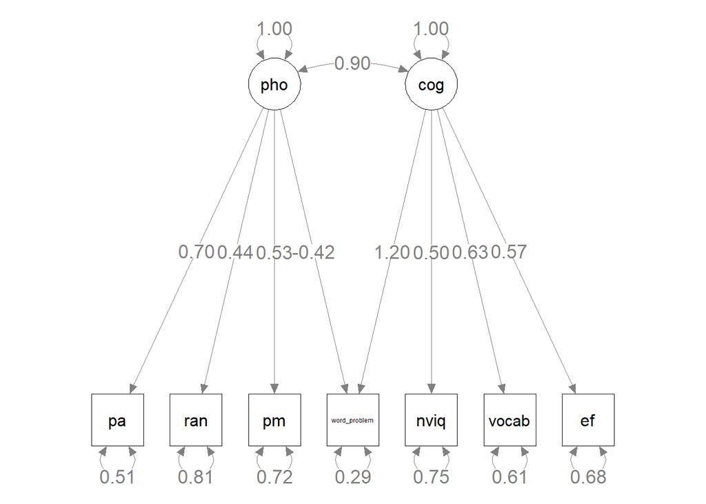

```r
plot(stage2)
```

Model fit statistic indicate a good fit, with Chi-square X2(12)=12.89, p=.377, CFI = .9995, RMSEA =.0022 High correlation between pho and cog, r=.90, p<.001 pho –> word problem was not significant, coef=-0.417, p=.414 cog –> word problem was significant, coef=1.197, p=.019

### Math accuracy

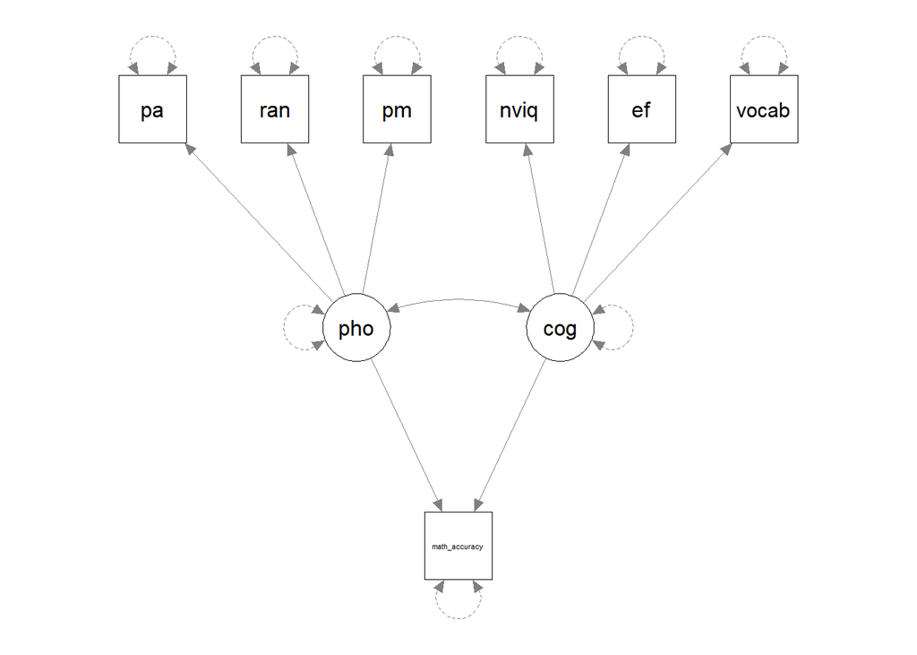

```r
observed_variables <- c('pa', 'ran', 'pm', 'nviq', 'vocab', 'ef', 'math_accuracy')
data <- prep_input(df, observed_variables)
lavaan_spec <- 'pho =~ pa + ran + pm
                cog =~ nviq + ef + vocab
                cog ~~ pho
                math_accuracy ~ cog + pho'

plot(lavaan_spec)
```

```r
RAM_spec <- lavaan2RAM(lavaan_spec, obs.variables=observed_variables)

stage1 <- tssem1(data$cor, data$n, method="REM") %>%
      rerun(autofixtau2 = TRUE)
```

```
## Running TSSEM1 Correlation with 42 parameters
```

```
##
## Beginning initial fit attempt
```

```
## Running TSSEM1 Correlation with 42 parameters
```

```
##
## Solution found
```

```
##
##  Solution found!  Final fit=-546.56679 (started at -546.56679)  (1 attempt(s): 1 valid, 0 errors)
```

```
## Running TSSEM1 Correlation with 42 parameters
```

```
##
## Beginning initial fit attempt
```

```
## Running TSSEM1 Correlation with 42 parameters
```

```
##
## Solution found
```

```
##
##  Solution found!  Final fit=-546.56679 (started at -546.56679)  (1 attempt(s): 1 valid, 0 errors)
```

```r
stage2 <- tssem2(stage1, RAM=RAM_spec, intervals.type="z") %>%
  rerun()
```

```
## Running TSSEM2 Correlation with 9 parameters
```

```
##
## Beginning initial fit attempt
```

```
## Running TSSEM2 Correlation with 9 parameters
```

```
##
##  Lowest minimum so far:  31.4242628327124
```

```
##
## Solution found
```

```
##
##  Solution found!  Final fit=31.424263 (started at 31.424263)  (1 attempt(s): 1 valid, 0 errors)
```

```r
summary(stage2)
```

```
##
## Call:
## wls(Cov = pooledS, aCov = aCov, n = tssem1.obj$total.n, RAM = RAM,
##     Amatrix = Amatrix, Smatrix = Smatrix, Fmatrix = Fmatrix,
##     diag.constraints = diag.constraints, cor.analysis = cor.analysis,
##     intervals.type = intervals.type, mx.algebras = mx.algebras,
##     model.name = model.name, suppressWarnings = suppressWarnings,
##     silent = silent, run = run)
##
## 95% confidence intervals: z statistic approximation
## Coefficients:
##                     Estimate Std.Error    lbound    ubound z value Pr(>|z|)
## efONcog             0.607686  0.031373  0.546196  0.669176 19.3697  < 2e-16 ***
## math_accuracyONcog  0.454831  0.238719 -0.013049  0.922711  1.9053  0.05674 .
## math_accuracyONpho  0.192601  0.232512 -0.263114  0.648317  0.8283  0.40747
## nviqONcog           0.504035  0.023635  0.457712  0.550358 21.3262  < 2e-16 ***
## paONpho             0.690248  0.024140  0.642935  0.737562 28.5937  < 2e-16 ***
## pmONpho             0.507247  0.022251  0.463637  0.550858 22.7970  < 2e-16 ***
## ranONpho            0.475264  0.021727  0.432680  0.517848 21.8743  < 2e-16 ***
## vocabONcog          0.600605  0.027824  0.546071  0.655140 21.5858  < 2e-16 ***
## phoWITHcog          0.904557  0.044589  0.817165  0.991949 20.2867  < 2e-16 ***
## ---
## Signif. codes:  0 '***' 0.001 '**' 0.01 '*' 0.05 '.' 0.1 ' ' 1
##
## Goodness-of-fit indices:
##                                                 Value
## Sample size                                16740.0000
## Chi-square of target model                    31.4243
## DF of target model                            12.0000
## p value of target model                        0.0017
## Number of constraints imposed on "Smatrix"     0.0000
## DF manually adjusted                           0.0000
## Chi-square of independence model            2483.9755
## DF of independence model                      21.0000
## RMSEA                                          0.0098
## RMSEA lower 95% CI                             0.0057
## RMSEA upper 95% CI                             0.0141
## SRMR                                           0.0360
## TLI                                            0.9862
## CFI                                            0.9921
## AIC                                            7.4243
## BIC                                          -85.2824
## OpenMx status1: 0 ("0" or "1": The optimization is considered fine.
## Other values indicate problems.)
```

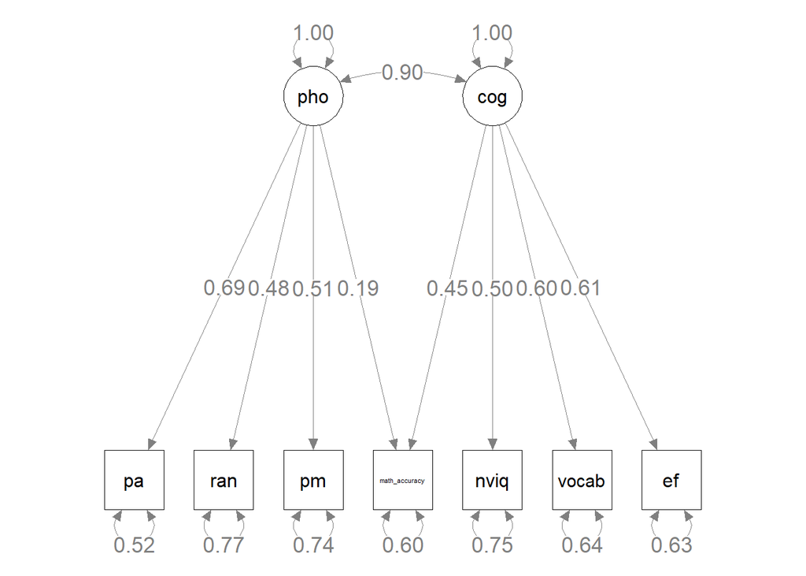

```r
plot(stage2)
```

Model fit statistic indicate a good fit, with Chi-square X2(12)=31.42, p=.002, CFI = .992, RMSEA =.010 High correlation between pho and cog, r=.90, p<.001 pho –> math acc was not significant, coef=.193, p=.407 cog –> math acc was not significant, coef=.455, p=.057

### Math fluency

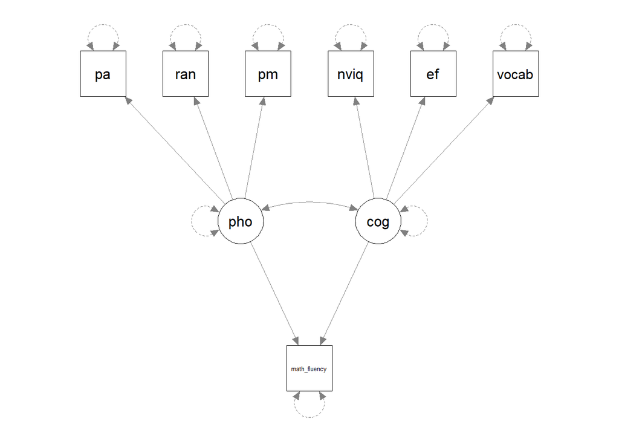

```r
observed_variables <- c('pa', 'ran', 'pm', 'nviq', 'vocab', 'ef', 'math_fluency')
data <- prep_input(df, observed_variables)
lavaan_spec <- 'pho =~ pa + ran + pm
                cog =~ nviq + ef + vocab
                cog ~~ pho
                math_fluency ~ cog + pho'

plot(lavaan_spec)
```

```r
RAM_spec <- lavaan2RAM(lavaan_spec, obs.variables=observed_variables)

stage1<-tssem1(data$cor, data$n, method="REM") %>%
      rerun(autofixtau2 = TRUE)
```

```
## Running TSSEM1 Correlation with 42 parameters
```

```
##
## Beginning initial fit attempt
```

```
## Running TSSEM1 Correlation with 42 parameters
```

```
##
##  Lowest minimum so far:  -450.050525635021
```

```
##
## Solution found
```

```
##
##  Solution found!  Final fit=-450.05053 (started at -450.05053)  (1 attempt(s): 1 valid, 0 errors)
```

```
## Running TSSEM1 Correlation with 42 parameters
```

```
##
## Beginning initial fit attempt
```

```
## Running TSSEM1 Correlation with 42 parameters
```

```
##
##  Lowest minimum so far:  -450.050525635066
```

```
##
## Solution found
```

```
##
##  Solution found!  Final fit=-450.05053 (started at -450.05053)  (1 attempt(s): 1 valid, 0 errors)
```

```r
stage2 <- tssem2(stage1, RAM=RAM_spec, intervals.type="z") %>%
  rerun()
```

```
## Running TSSEM2 Correlation with 9 parameters
```

```
##
## Beginning initial fit attempt
```

```
## Running TSSEM2 Correlation with 9 parameters
```

```
##
##  Lowest minimum so far:  40.5588099929088
```

```
##
## Solution found
```

```
##
##  Solution found!  Final fit=40.55881 (started at 40.55881)  (1 attempt(s): 1 valid, 0 errors)
```

```r
summary(stage2)
```

```
##
## Call:
## wls(Cov = pooledS, aCov = aCov, n = tssem1.obj$total.n, RAM = RAM,
##     Amatrix = Amatrix, Smatrix = Smatrix, Fmatrix = Fmatrix,
##     diag.constraints = diag.constraints, cor.analysis = cor.analysis,
##     intervals.type = intervals.type, mx.algebras = mx.algebras,
##     model.name = model.name, suppressWarnings = suppressWarnings,
##     silent = silent, run = run)
##
## 95% confidence intervals: z statistic approximation
## Coefficients:
##                    Estimate Std.Error    lbound    ubound z value Pr(>|z|)
## efONcog            0.590422  0.033229  0.525294  0.655549 17.7682  < 2e-16 ***
## math_fluencyONcog  0.069713  0.288923 -0.496566  0.635992  0.2413  0.80933
## math_fluencyONpho  0.536593  0.280039 -0.012272  1.085459  1.9161  0.05535 .
## nviqONcog          0.506315  0.023984  0.459308  0.553322 21.1110  < 2e-16 ***
## paONpho            0.679062  0.026355  0.627407  0.730716 25.7661  < 2e-16 ***
## pmONpho            0.500768  0.023191  0.455314  0.546222 21.5931  < 2e-16 ***
## ranONpho           0.488926  0.023361  0.443140  0.534711 20.9295  < 2e-16 ***
## vocabONcog         0.606520  0.029258  0.549175  0.663864 20.7300  < 2e-16 ***
## phoWITHcog         0.905285  0.045788  0.815542  0.995028 19.7711  < 2e-16 ***
## ---
## Signif. codes:  0 '***' 0.001 '**' 0.01 '*' 0.05 '.' 0.1 ' ' 1
##
## Goodness-of-fit indices:
##                                                 Value
## Sample size                                17064.0000
## Chi-square of target model                    40.5588
## DF of target model                            12.0000
## p value of target model                        0.0001
## Number of constraints imposed on "Smatrix"     0.0000
## DF manually adjusted                           0.0000
## Chi-square of independence model            1949.6132
## DF of independence model                      21.0000
## RMSEA                                          0.0118
## RMSEA lower 95% CI                             0.0079
## RMSEA upper 95% CI                             0.0159
## SRMR                                           0.0419
## TLI                                            0.9741
## CFI                                            0.9852
## AIC                                           16.5588
## BIC                                          -76.3779
## OpenMx status1: 0 ("0" or "1": The optimization is considered fine.
## Other values indicate problems.)
```

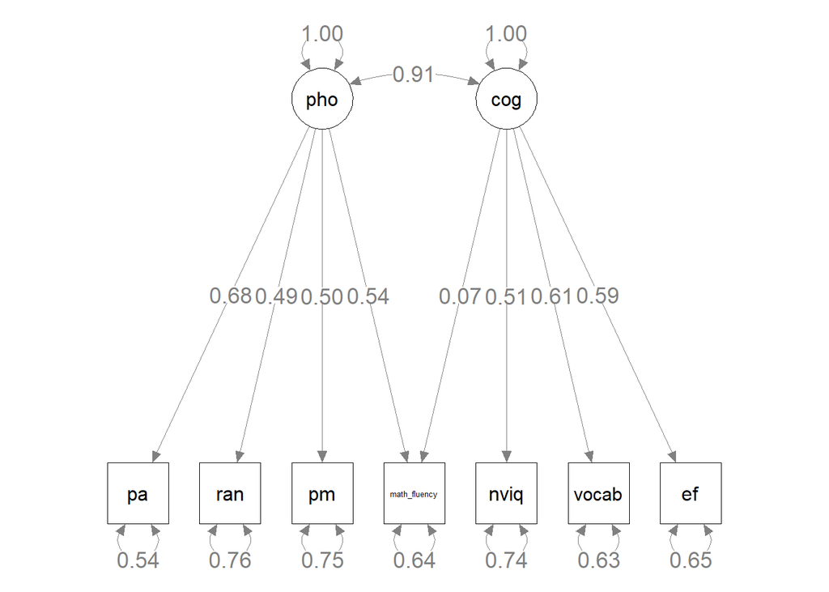

```r
plot(stage2)
```

## Three IVs models

- Phonological skill (pho): a latent variable that is measured by pa, ran, and pm
- Cognitive skill (cog): a latent variable that is measured by nviq and ef
- Vocabulary knowledge (vocab): a observed variable that is measured by vocab
- *Due to small number of observation in vocab and cog, the SE is very high for any coefficient related to these factors*

### Number knowledge

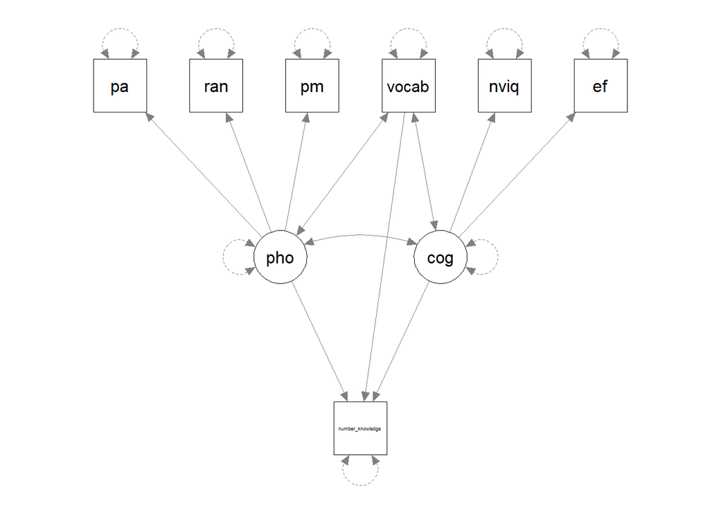

```r
observed_variables <- c('pa', 'ran', 'pm', 'nviq', 'vocab', 'ef', 'number_knowledge')

# Since not all variable will be used from the raw data, we have to call prep_input
# to create a trimmed data set
data <- prep_input(df, observed_variables)

lavaan_spec <- 'pho =~ pa + ran + pm
                cog =~ nviq + ef
                cog ~~ pho
                cog ~~ vocab
                pho ~~ vocab
                number_knowledge ~ cog + pho + vocab'

plot(lavaan_spec)
```

```r
RAM_spec <- lavaan2RAM(lavaan_spec, obs.variables=observed_variables)

stage1 <-tssem1(data$cor, data$n, method="REM") %>%
      rerun(autofixtau2 = TRUE)
```

```
## Running TSSEM1 Correlation with 42 parameters
```

```
##
## Beginning initial fit attempt
```

```
## Running TSSEM1 Correlation with 42 parameters
```

```
##
##  Lowest minimum so far:  -499.566630141866
```

```
##
## Solution found
```

```
##
##  Solution found!  Final fit=-499.56663 (started at -499.56663)  (1 attempt(s): 1 valid, 0 errors)
```

```
## Running TSSEM1 Correlation with 42 parameters
```

```
##
## Beginning initial fit attempt
```

```
## Running TSSEM1 Correlation with 42 parameters
```

```
##
## Solution found
```

```
##
##  Solution found!  Final fit=-499.56663 (started at -499.56663)  (1 attempt(s): 1 valid, 0 errors)
```

```r
stage2 <- tssem2(stage1, RAM=RAM_spec, intervals.type="z") %>%
  rerun()
```

```
## Running TSSEM2 Correlation with 12 parameters
```

```
##
## Beginning initial fit attempt
```

```
## Running TSSEM2 Correlation with 12 parameters
```

```
##
##  Lowest minimum so far:  13.5359594257359
```

```
##  Not all eigenvalues of the Hessian are positive: 14399.0163374497, 5554.88730870842, 4618.47673529227, 4124.70159101713, 3354.85095034487, 2495.61587805297, 2089.05943443275, 1857.65742139471, 584.434725050796, 178.328633913601, 4.3017518155075, -6.6151637242372e-05
```

```
##
## Beginning fit attempt 1 of at maximum 10 extra tries
```

```
## Running TSSEM2 Correlation with 12 parameters
```

```
##  Not all eigenvalues of the Hessian are positive: 14399.0163374497, 5554.88730870842, 4618.47673529227, 4124.70159101713, 3354.85095034487, 2495.61587805297, 2089.05943443275, 1857.65742139471, 584.434725050796, 178.328633913601, 4.3017518155075, -6.6151637242372e-05
```

```
##
## Beginning fit attempt 2 of at maximum 10 extra tries
```

```
## Running TSSEM2 Correlation with 12 parameters
```

```
##  Not all eigenvalues of the Hessian are positive: 13475.6451167648, 5510.51719236663, 4740.043464163, 4147.84075477034, 3341.81108299191, 2251.94581223292, 2056.27026174341, 1346.88051689531, 496.475614167876, 236.161943425126, 5.8393833400124, -1.23093151192057e-05
```

```
##
## Beginning fit attempt 3 of at maximum 10 extra tries
```

```
## Running TSSEM2 Correlation with 12 parameters
```

```
##
## Solution found
```

```
##
##  Solution found!  Final fit=13.535959 (started at 13.535959)  (4 attempt(s): 4 valid, 0 errors)
```

```r
summary(stage2)
```

```
##
## Call:
## wls(Cov = pooledS, aCov = aCov, n = tssem1.obj$total.n, RAM = RAM,
##     Amatrix = Amatrix, Smatrix = Smatrix, Fmatrix = Fmatrix,
##     diag.constraints = diag.constraints, cor.analysis = cor.analysis,
##     intervals.type = intervals.type, mx.algebras = mx.algebras,
##     model.name = model.name, suppressWarnings = suppressWarnings,
##     silent = silent, run = run)
##
## 95% confidence intervals: z statistic approximation
## Coefficients:
##                            Estimate   Std.Error      lbound      ubound z value
## efONcog                    0.578240    0.042928    0.494101    0.662378 13.4699
## number_knowledgeONcog      0.664582   48.032008  -93.476423   94.805587  0.0138
## number_knowledgeONpho      0.218473    3.578512   -6.795281    7.232227  0.0611
## number_knowledgeONvocab   -0.446067   80.449653 -158.124490  157.232357 -0.0055
## nviqONcog                  0.485362    0.035693    0.415404    0.555319 13.5981
## paONpho                    0.699938    0.026397    0.648200    0.751676 26.5154
## pmONpho                    0.514973    0.023743    0.468438    0.561508 21.6897
## ranONpho                   0.450955    0.022883    0.406105    0.495804 19.7072
## phoWITHcog                 0.893246    0.073499    0.749190    1.037303 12.1531
## cogWITHvocab               0.636421    0.058586    0.521595    0.751248 10.8630
## phoWITHvocab               0.577394    0.033258    0.512210    0.642579 17.3610
## vocabWITHvocab             0.694408   52.119691 -101.458308  102.847125  0.0133
##                         Pr(>|z|)
## efONcog                   <2e-16 ***
## number_knowledgeONcog     0.9890
## number_knowledgeONpho     0.9513
## number_knowledgeONvocab   0.9956
## nviqONcog                 <2e-16 ***
## paONpho                   <2e-16 ***
## pmONpho                   <2e-16 ***
## ranONpho                  <2e-16 ***
## phoWITHcog                <2e-16 ***
## cogWITHvocab              <2e-16 ***
## phoWITHvocab              <2e-16 ***
## vocabWITHvocab            0.9894
## ---
## Signif. codes:  0 '***' 0.001 '**' 0.01 '*' 0.05 '.' 0.1 ' ' 1
##
## Goodness-of-fit indices:
##                                                 Value
## Sample size                                16434.0000
## Chi-square of target model                    13.5360
## DF of target model                             9.0000
## p value of target model                        0.1398
## Number of constraints imposed on "Smatrix"     0.0000
## DF manually adjusted                           0.0000
## Chi-square of independence model            1977.8627
## DF of independence model                      21.0000
## RMSEA                                          0.0055
## RMSEA lower 95% CI                             0.0000
## RMSEA upper 95% CI                             0.0112
## SRMR                                           0.0258
## TLI                                            0.9946
## CFI                                            0.9977
## AIC                                           -4.4640
## BIC                                          -73.8280
## OpenMx status1: 0 ("0" or "1": The optimization is considered fine.
## Other values indicate problems.)
```

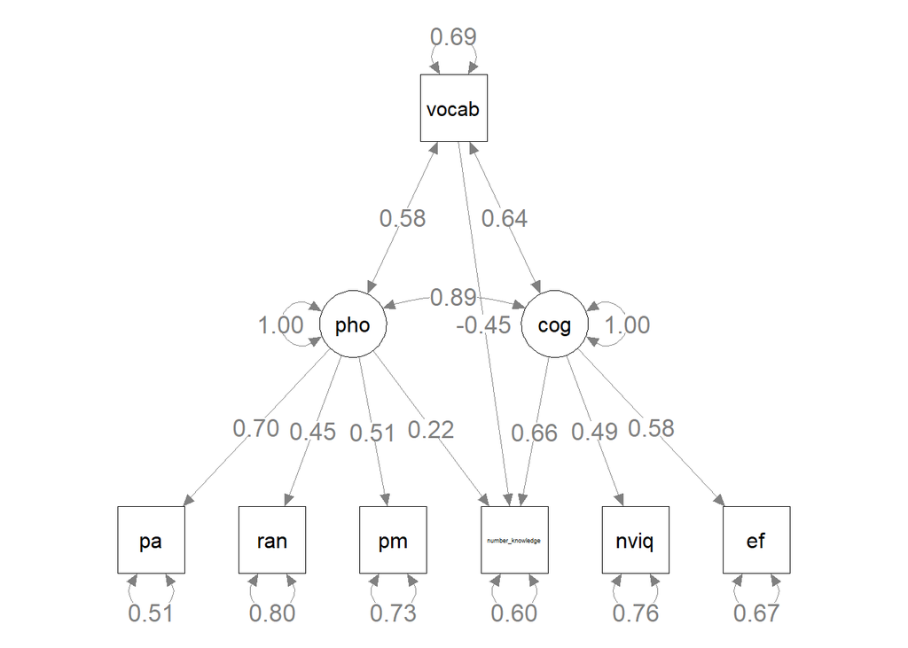

```r
plot(stage2)
```

Result summary: - Model fit statistic indicate a good fit, with Chi-square X2(9)=13.54, p=0.1398, CFI = 0.9977, RMSEA = 0.0055 - pho –> number_knowledge was not significant - cog –> number_knowledge was not significant - vocab –> number_knowledge was not significant - *Due to small n in vocab, the standard error is quite high*

### Calculation

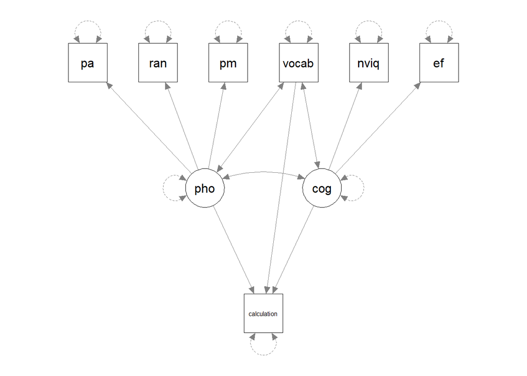

```r
observed_variables <- c('pa', 'ran', 'pm', 'nviq', 'vocab', 'ef', 'calculation')
data <- prep_input(df, observed_variables)
lavaan_spec <- 'pho =~ pa + ran + pm
                cog =~ nviq + ef
                cog ~~ pho
                cog ~~ vocab
                pho ~~ vocab
                calculation ~ cog + pho + vocab'

plot(lavaan_spec)
```

```r
RAM_spec <- lavaan2RAM(lavaan_spec, obs.variables=observed_variables)

stage1<-tssem1(data$cor, data$n, method="REM") %>%
      rerun(autofixtau2 = TRUE)
```

```
## Running TSSEM1 Correlation with 42 parameters
```

```
##
## Beginning initial fit attempt
```

```
## Running TSSEM1 Correlation with 42 parameters
```

```
##
##  Lowest minimum so far:  -492.937673059093
```

```
##
## Solution found
```

```
##
##  Solution found!  Final fit=-492.93767 (started at -492.93767)  (1 attempt(s): 1 valid, 0 errors)
```

```
## Running TSSEM1 Correlation with 42 parameters
```

```
##
## Beginning initial fit attempt
```

```
## Running TSSEM1 Correlation with 42 parameters
```

```
##
##  Lowest minimum so far:  -492.937673059728
```

```
##
## Solution found
```

```
##
##  Solution found!  Final fit=-492.93767 (started at -492.93767)  (1 attempt(s): 1 valid, 0 errors)
```

```r
stage2 <- tssem2(stage1, RAM=RAM_spec, intervals.type="z") %>%
  rerun()
```

```
## Running TSSEM2 Correlation with 12 parameters
```

```
##
## Beginning initial fit attempt
```

```
## Running TSSEM2 Correlation with 12 parameters
```

```
##
##  Lowest minimum so far:  21.2188767003612
```

```
##
## Solution found
```

```
##
##  Solution found!  Final fit=21.218877 (started at 21.218877)  (1 attempt(s): 1 valid, 0 errors)
```

```r
summary(stage2)
```

```
##
## Call:
## wls(Cov = pooledS, aCov = aCov, n = tssem1.obj$total.n, RAM = RAM,
##     Amatrix = Amatrix, Smatrix = Smatrix, Fmatrix = Fmatrix,
##     diag.constraints = diag.constraints, cor.analysis = cor.analysis,
##     intervals.type = intervals.type, mx.algebras = mx.algebras,
##     model.name = model.name, suppressWarnings = suppressWarnings,
##     silent = silent, run = run)
##
## 95% confidence intervals: z statistic approximation
## Coefficients:
##                       Estimate   Std.Error      lbound      ubound z value
## calculationONcog      0.626391   59.289992 -115.579858  116.832639  0.0106
## calculationONpho      0.159405    5.660539  -10.935049   11.253858  0.0282
## calculationONvocab   -0.212889  102.296680 -200.710697  200.284919 -0.0021
## efONcog               0.561787    0.041683    0.480091    0.643483 13.4778
## nviqONcog             0.500474    0.036482    0.428970    0.571978 13.7183
## paONpho               0.690792    0.025843    0.640142    0.741443 26.7308
## pmONpho               0.509203    0.022878    0.464364    0.554043 22.2576
## ranONpho              0.468967    0.023133    0.423628    0.514307 20.2727
## phoWITHcog            0.892212    0.073119    0.748902    1.035522 12.2022
## cogWITHvocab          0.628806    0.058886    0.513392    0.744220 10.6784
## phoWITHvocab          0.572282    0.032778    0.508038    0.636525 17.4594
## vocabWITHvocab        0.743626  167.031570 -326.632236  328.119487  0.0045
##                    Pr(>|z|)
## calculationONcog     0.9916
## calculationONpho     0.9775
## calculationONvocab   0.9983
## efONcog              <2e-16 ***
## nviqONcog            <2e-16 ***
## paONpho              <2e-16 ***
## pmONpho              <2e-16 ***
## ranONpho             <2e-16 ***
## phoWITHcog           <2e-16 ***
## cogWITHvocab         <2e-16 ***
## phoWITHvocab         <2e-16 ***
## vocabWITHvocab       0.9964
## ---
## Signif. codes:  0 '***' 0.001 '**' 0.01 '*' 0.05 '.' 0.1 ' ' 1
##
## Goodness-of-fit indices:
##                                                 Value
## Sample size                                16589.0000
## Chi-square of target model                    21.2189
## DF of target model                             9.0000
## p value of target model                        0.0117
## Number of constraints imposed on "Smatrix"     0.0000
## DF manually adjusted                           0.0000
## Chi-square of independence model            2119.3335
## DF of independence model                      21.0000
## RMSEA                                          0.0090
## RMSEA lower 95% CI                             0.0040
## RMSEA upper 95% CI                             0.0141
## SRMR                                           0.0314
## TLI                                            0.9864
## CFI                                            0.9942
## AIC                                            3.2189
## BIC                                          -66.2296
## OpenMx status1: 0 ("0" or "1": The optimization is considered fine.
## Other values indicate problems.)
```

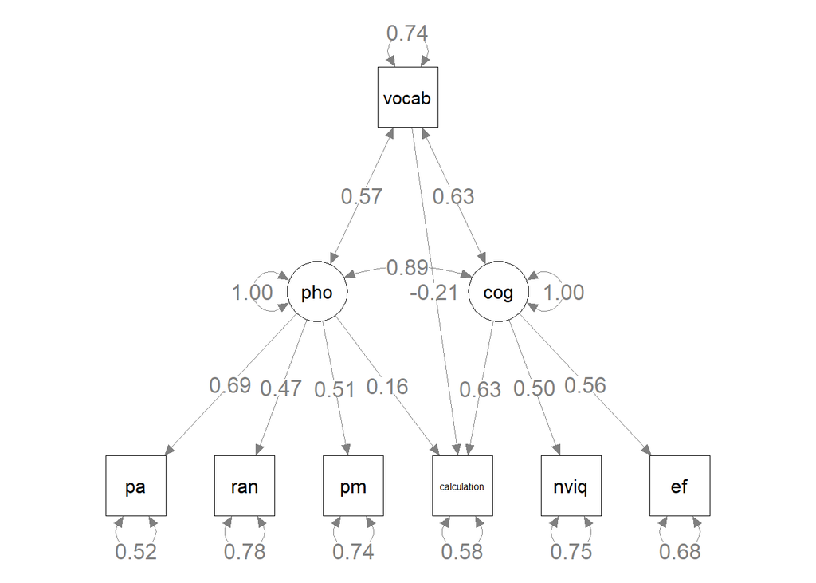

```r
plot(stage2)
```

Model fit statistic indicate a good fit, with Chi-square X2(9)=21.22, p=.012, CFI = 0.9942, RMSEA = 0.0090 pho –> calculation was not significant cog –> calculation was not significant vocab –> calculation was not significant

### Word problem

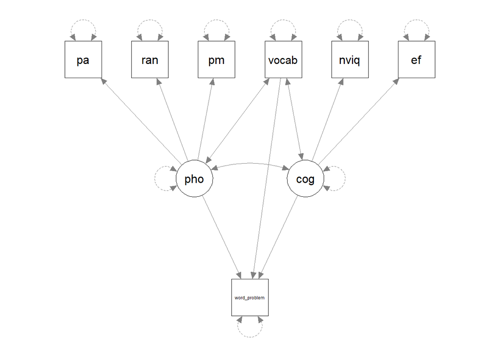

```r
observed_variables <- c('pa', 'ran', 'pm', 'nviq', 'vocab', 'ef', 'word_problem')
data <- prep_input(df, observed_variables)
lavaan_spec <- 'pho =~ pa + ran + pm
                cog =~ nviq + ef
                cog ~~ pho
                cog ~~ vocab
                pho ~~ vocab
                word_problem ~ cog + pho + vocab'

plot(lavaan_spec)
```

```r
RAM_spec <- lavaan2RAM(lavaan_spec, obs.variables=observed_variables)

stage1<-tssem1(data$cor, data$n, method="REM") %>%
      rerun(autofixtau2 = TRUE)
```

```
## Running TSSEM1 Correlation with 42 parameters
```

```
##
## Beginning initial fit attempt
```

```
## Running TSSEM1 Correlation with 42 parameters
```

```
##
##  Lowest minimum so far:  -387.349556995899
```

```
##
## Solution found
```

```
##
##  Solution found!  Final fit=-387.34956 (started at -387.34956)  (1 attempt(s): 1 valid, 0 errors)
```

```
## Running TSSEM1 Correlation with 42 parameters
```

```
##
## Beginning initial fit attempt
```

```
## Running TSSEM1 Correlation with 42 parameters
```

```
##
##  Lowest minimum so far:  -387.349556995958
```

```
##
## Solution found
```

```
##
##  Solution found!  Final fit=-387.34956 (started at -387.34956)  (1 attempt(s): 1 valid, 0 errors)
```

```r
stage2 <- tssem2(stage1, RAM=RAM_spec, intervals.type="z") %>%
  rerun()
```

```
## Running TSSEM2 Correlation with 12 parameters
```

```
##
## Beginning initial fit attempt
```

```
## Running TSSEM2 Correlation with 12 parameters
```

```
##
##  Lowest minimum so far:  10.9109387400105
```

```
##
## Solution found
```

```
##
##  Solution found!  Final fit=10.910939 (started at 10.910939)  (1 attempt(s): 1 valid, 0 errors)
```

```r
summary(stage2)
```

```
##
## Call:
## wls(Cov = pooledS, aCov = aCov, n = tssem1.obj$total.n, RAM = RAM,
##     Amatrix = Amatrix, Smatrix = Smatrix, Fmatrix = Fmatrix,
##     diag.constraints = diag.constraints, cor.analysis = cor.analysis,
##     intervals.type = intervals.type, mx.algebras = mx.algebras,
##     model.name = model.name, suppressWarnings = suppressWarnings,
##     silent = silent, run = run)
##
## 95% confidence intervals: z statistic approximation
## Coefficients:
##                        Estimate   Std.Error      lbound      ubound z value
## efONcog              5.6148e-01  4.1584e-02  4.7998e-01  6.4299e-01 13.5022
## nviqONcog            4.9976e-01  3.6330e-02  4.2856e-01  5.7097e-01 13.7561
## paONpho              7.0446e-01  2.7984e-02  6.4962e-01  7.5931e-01 25.1738
## pmONpho              5.2575e-01  2.4713e-02  4.7732e-01  5.7419e-01 21.2746
## ranONpho             4.3467e-01  2.3996e-02  3.8764e-01  4.8170e-01 18.1140
## word_problemONcog    3.0118e+00  3.1101e+02 -6.0655e+02  6.1258e+02  0.0097
## word_problemONpho   -1.5264e-01  6.0543e+01 -1.1881e+02  1.1851e+02 -0.0025
## word_problemONvocab -3.1866e+00  5.7828e+02 -1.1366e+03  1.1302e+03 -0.0055
## phoWITHcog           8.8436e-01  7.2794e-02  7.4169e-01  1.0270e+00 12.1488
## cogWITHvocab         6.3036e-01  5.8700e-02  5.1531e-01  7.4541e-01 10.7387
## phoWITHvocab         5.8027e-01  3.3455e-02  5.1470e-01  6.4584e-01 17.3447
## vocabWITHvocab       4.1971e-01  3.6257e+00 -6.6866e+00  7.5260e+00  0.1158
##                     Pr(>|z|)
## efONcog               <2e-16 ***
## nviqONcog             <2e-16 ***
## paONpho               <2e-16 ***
## pmONpho               <2e-16 ***
## ranONpho              <2e-16 ***
## word_problemONcog     0.9923
## word_problemONpho     0.9980
## word_problemONvocab   0.9956
## phoWITHcog            <2e-16 ***
## cogWITHvocab          <2e-16 ***
## phoWITHvocab          <2e-16 ***
## vocabWITHvocab        0.9078
## ---
## Signif. codes:  0 '***' 0.001 '**' 0.01 '*' 0.05 '.' 0.1 ' ' 1
##
## Goodness-of-fit indices:
##                                                 Value
## Sample size                                15237.0000
## Chi-square of target model                    10.9109
## DF of target model                             9.0000
## p value of target model                        0.2819
## Number of constraints imposed on "Smatrix"     0.0000
## DF manually adjusted                           0.0000
## Chi-square of independence model            1884.5841
## DF of independence model                      21.0000
## RMSEA                                          0.0037
## RMSEA lower 95% CI                             0.0000
## RMSEA upper 95% CI                             0.0103
## SRMR                                           0.0268
## TLI                                            0.9976
## CFI                                            0.9990
## AIC                                           -7.0891
## BIC                                          -75.7724
## OpenMx status1: 0 ("0" or "1": The optimization is considered fine.
## Other values indicate problems.)
```

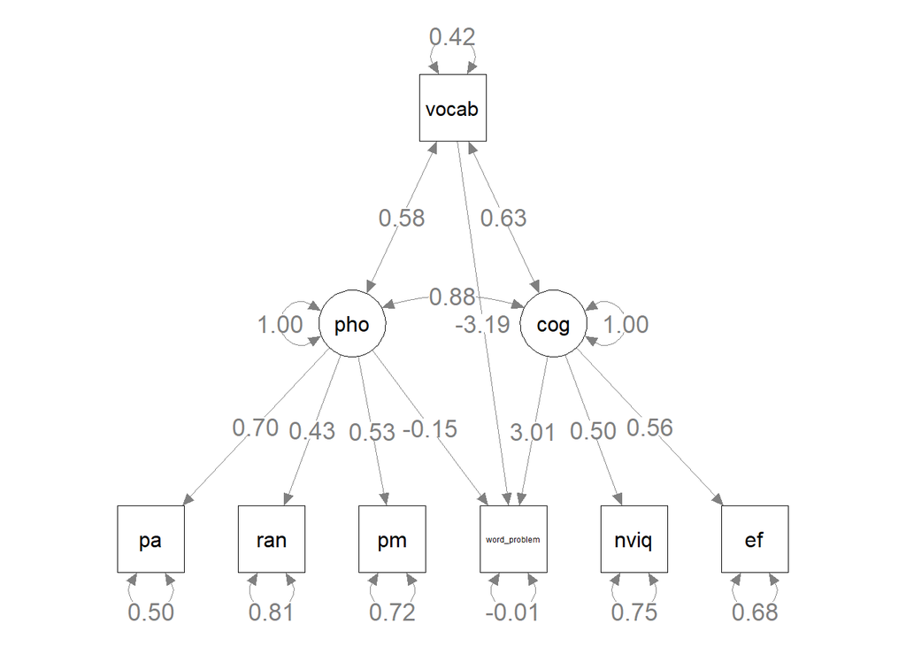

```r
plot(stage2)
```

Model fit statistic indicate a good fit, with Chi-square X2(9)=10.9110, p=0.2819, CFI = 0.9990, RMSEA = 0.0037 pho –> word problem was not significant cog –> word problem was not significant vocab –> word problem was not significant

### Math accuracy

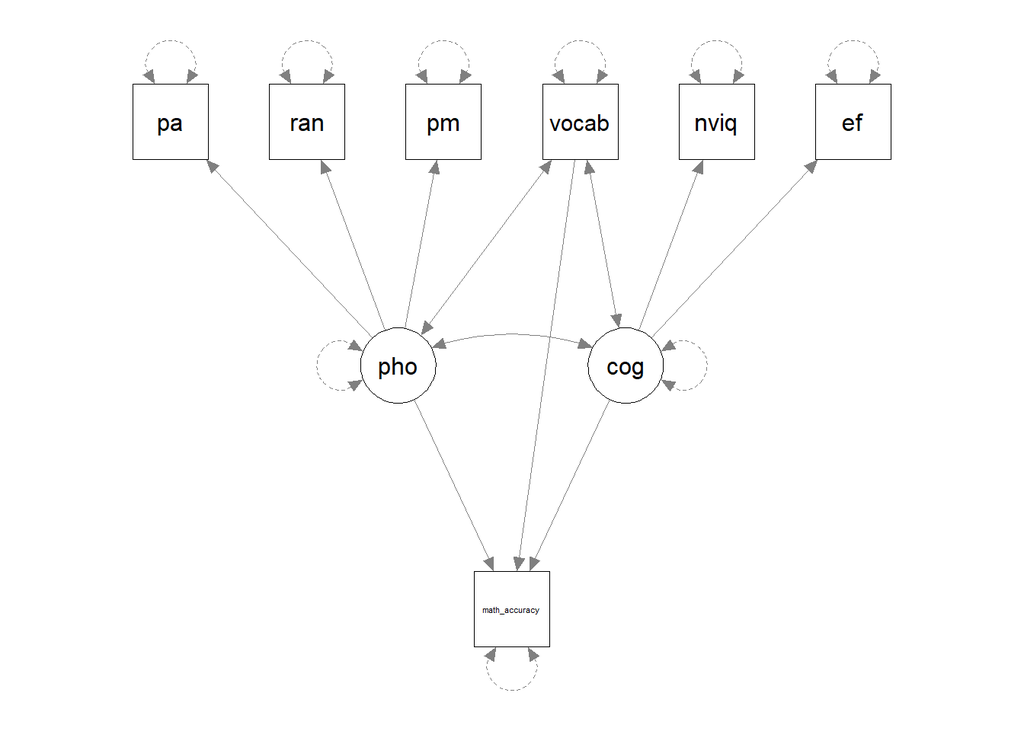

```r
observed_variables <- c('pa', 'ran', 'pm', 'nviq', 'vocab', 'ef', 'math_accuracy')
data <- prep_input(df, observed_variables)
lavaan_spec <- 'pho =~ pa + ran + pm
                cog =~ nviq + ef
                cog ~~ pho
                cog ~~ vocab
                pho ~~ vocab
                math_accuracy ~ cog + pho + vocab'

plot(lavaan_spec)
```

```r
RAM_spec <- lavaan2RAM(lavaan_spec, obs.variables=observed_variables)

stage1 <- tssem1(data$cor, data$n, method="REM") %>%
      rerun(autofixtau2 = TRUE)
```

```
## Running TSSEM1 Correlation with 42 parameters
```

```
##
## Beginning initial fit attempt
```

```
## Running TSSEM1 Correlation with 42 parameters
```

```
##
##  Lowest minimum so far:  -546.566414186466
```

```
##
## Solution found
```

```
##
##  Solution found!  Final fit=-546.56641 (started at -546.56641)  (1 attempt(s): 1 valid, 0 errors)
```

```
## Running TSSEM1 Correlation with 42 parameters
```

```
##
## Beginning initial fit attempt
```

```
## Running TSSEM1 Correlation with 42 parameters
```

```
##
##  Lowest minimum so far:  -546.566414186983
```

```
##
## Solution found
```

```
##
##  Solution found!  Final fit=-546.56641 (started at -546.56641)  (1 attempt(s): 1 valid, 0 errors)
```

```r
stage2 <- tssem2(stage1, RAM=RAM_spec, intervals.type="z") %>%
  rerun()
```

```
## Running TSSEM2 Correlation with 12 parameters
```

```
##
## Beginning initial fit attempt
```

```
## Running TSSEM2 Correlation with 12 parameters
```

```
##
##  Lowest minimum so far:  19.6483599052315
```

```
##  OpenMx status code 6 not in list of acceptable status codes, (0,1)
```

```
##  Not all eigenvalues of the Hessian are positive: 1465257661150.03, 749264926733.031, 163685380341.184, 6179.3150183669, 4868.94935231088, 4104.61626201929, 3606.97566079416, 1977.58701814681, 568.750985296173, 0.000103865354676645, -2.46129552264768e-05, -0.000932331562410466
```

```
##
## Beginning fit attempt 1 of at maximum 10 extra tries
```

```
## Running TSSEM2 Correlation with 12 parameters
```

```
##
##  Lowest minimum so far:  19.6131486807114
```

```
##  OpenMx status code 6 not in list of acceptable status codes, (0,1)
```

```
##  Not all eigenvalues of the Hessian are positive: 1367006976191.76, 717770016934.29, 132118745152.725, 6212.91086416061, 4860.40956135955, 4123.74773312855, 3643.93702943175, 1984.07380191251, 649.989783033082, 2.70936098357359e-05, 7.00302815730616e-08, -2.45057506899925e-08
```

```
##
## Beginning fit attempt 2 of at maximum 10 extra tries
```

```
## Running TSSEM2 Correlation with 12 parameters
```

```
##
##  Lowest minimum so far:  19.6131472102397
```

```
##  OpenMx status code 6 not in list of acceptable status codes, (0,1)
```

```
##  Not all eigenvalues of the Hessian are positive: 1367050912604.46, 717772942266.052, 132125047783.432, 6212.76370919442, 4860.15724137507, 4123.54095665364, 3643.88095757863, 1984.03194899361, 650.173140208758, 2.80051070677022e-05, 8.57488680610101e-08, -1.3618785047491e-07
```

```
##
## Beginning fit attempt 3 of at maximum 10 extra tries
```

```
## Running TSSEM2 Correlation with 12 parameters
```

```
##
##  Fit attempt worse than current best:  290092.833790374 vs 19.6131472102397
```

```
##
## Beginning fit attempt 4 of at maximum 10 extra tries
```

```
## Running TSSEM2 Correlation with 12 parameters
```

```
##
##  Fit attempt worse than current best:  1184.65350697299 vs 19.6131472102397
```

```
##
## Beginning fit attempt 5 of at maximum 10 extra tries
```

```
## Running TSSEM2 Correlation with 12 parameters
```

```
##
##  Fit attempt worse than current best:  406.459922497459 vs 19.6131472102397
```

```
##
## Beginning fit attempt 6 of at maximum 10 extra tries
```

```
## Running TSSEM2 Correlation with 12 parameters
```

```
##
##  Fit attempt worse than current best:  32562.0617389562 vs 19.6131472102397
```

```
##
## Beginning fit attempt 7 of at maximum 10 extra tries
```

```
## Running TSSEM2 Correlation with 12 parameters
```

```
##
##  Fit attempt worse than current best:  64.3409012171689 vs 19.6131472102397
```

```
##
## Beginning fit attempt 8 of at maximum 10 extra tries
```

```
## Running TSSEM2 Correlation with 12 parameters
```

```
##
##  Fit attempt worse than current best:  1676.85183867662 vs 19.6131472102397
```

```
##
## Beginning fit attempt 9 of at maximum 10 extra tries
```

```
## Running TSSEM2 Correlation with 12 parameters
```

```
##
##  Fit attempt worse than current best:  1085.81127822551 vs 19.6131472102397
```

```
##
## Beginning fit attempt 10 of at maximum 10 extra tries
```

```
## Running TSSEM2 Correlation with 12 parameters
```

```
##
##  Fit attempt worse than current best:  739.442267387546 vs 19.6131472102397
```

```
##
## Retry limit reached
```

```
##
##  Retry limit reached; Best fit=19.613147 (started at 19.649208)  (11 attempt(s): 11 valid, 0 errors)
```

```
##
##  Uncertain solution found - consider parameter validity, try again, increase extraTries, change inits, change model, or check data!
```

```r
summary(stage2)
```

```
##
## Call:
## wls(Cov = pooledS, aCov = aCov, n = tssem1.obj$total.n, RAM = RAM,
##     Amatrix = Amatrix, Smatrix = Smatrix, Fmatrix = Fmatrix,
##     diag.constraints = diag.constraints, cor.analysis = cor.analysis,
##     intervals.type = intervals.type, mx.algebras = mx.algebras,
##     model.name = model.name, suppressWarnings = suppressWarnings,
##     silent = silent, run = run)
##
## 95% confidence intervals: z statistic approximation
## Coefficients:
##                         Estimate   Std.Error      lbound      ubound   z value
## efONcog               5.7380e-01  7.5309e+01 -1.4703e+02  1.4818e+02    0.0076
## math_accuracyONcog    7.7244e+03  1.1243e+02  7.5041e+03  7.9448e+03   68.7061
## math_accuracyONpho    9.2564e+02  1.1901e+02  6.9239e+02  1.1589e+03    7.7781
## math_accuracyONvocab -1.3593e+04  7.1952e+01 -1.3734e+04 -1.3452e+04 -188.9151
## nviqONcog             4.9608e-01  9.3706e+01 -1.8316e+02  1.8416e+02    0.0053
## paONpho               6.9253e-01  1.0801e+02 -2.1100e+02  2.1239e+02    0.0064
## pmONpho               5.0773e-01  9.4742e+01 -1.8518e+02  1.8620e+02    0.0054
## ranONpho              4.7133e-01  1.0009e+02 -1.9571e+02  1.9665e+02    0.0047
## phoWITHcog            8.9059e-01  8.1519e+05 -1.5977e+06  1.5977e+06    0.0000
## cogWITHvocab          6.2887e-01  8.3773e+05 -1.6419e+06  1.6419e+06    0.0000
## phoWITHvocab          5.7415e-01  1.4374e+06 -2.8173e+06  2.8173e+06    0.0000
## vocabWITHvocab        3.9644e-01  1.0007e+06 -1.9613e+06  1.9613e+06    0.0000
##                       Pr(>|z|)
## efONcog                 0.9939
## math_accuracyONcog   < 2.2e-16 ***
## math_accuracyONpho   7.327e-15 ***
## math_accuracyONvocab < 2.2e-16 ***
## nviqONcog               0.9958
## paONpho                 0.9949
## pmONpho                 0.9957
## ranONpho                0.9962
## phoWITHcog              1.0000
## cogWITHvocab            1.0000
## phoWITHvocab            1.0000
## vocabWITHvocab          1.0000
## ---
## Signif. codes:  0 '***' 0.001 '**' 0.01 '*' 0.05 '.' 0.1 ' ' 1
##
## Goodness-of-fit indices:
##                                                 Value
## Sample size                                16740.0000
## Chi-square of target model                    19.6131
## DF of target model                             9.0000
## p value of target model                        0.0205
## Number of constraints imposed on "Smatrix"     0.0000
## DF manually adjusted                           0.0000
## Chi-square of independence model            2483.9633
## DF of independence model                      21.0000
## RMSEA                                          0.0084
## RMSEA lower 95% CI                             0.0031
## RMSEA upper 95% CI                             0.0135
## SRMR                                           0.0279
## TLI                                            0.9899
## CFI                                            0.9957
## AIC                                            1.6131
## BIC                                          -67.9169
## OpenMx status1: 6 ("0" or "1": The optimization is considered fine.
## Other values indicate problems.)
```

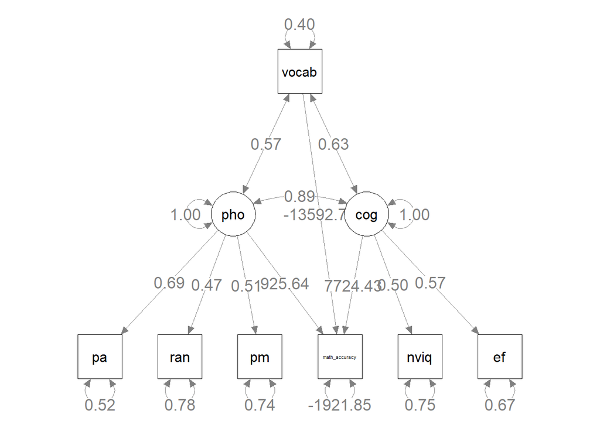

```r
plot(stage2)
```

- cannot fit model properly

### Math fluency

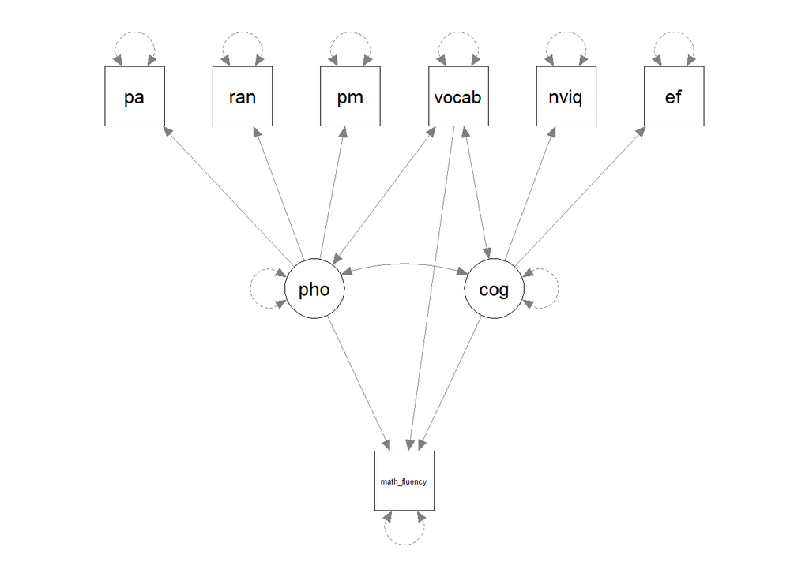

```r
observed_variables <- c('pa', 'ran', 'pm', 'nviq', 'vocab', 'ef', 'math_fluency')
data <- prep_input(df, observed_variables)
lavaan_spec <- 'pho =~ pa + ran + pm
                cog =~ nviq + ef
                cog ~~ pho
                cog ~~ vocab
                pho ~~ vocab
                math_fluency ~ cog + pho + vocab'

plot(lavaan_spec)
```

```r
RAM_spec <- lavaan2RAM(lavaan_spec, obs.variables=observed_variables)

stage1<-tssem1(data$cor, data$n, method="REM") %>%
      rerun(autofixtau2 = TRUE)
```

```
## Running TSSEM1 Correlation with 42 parameters
```

```
##
## Beginning initial fit attempt
```

```
## Running TSSEM1 Correlation with 42 parameters
```

```
##
##  Lowest minimum so far:  -450.050475760024
```

```
##
## Solution found
```

```
##
##  Solution found!  Final fit=-450.05048 (started at -450.05048)  (1 attempt(s): 1 valid, 0 errors)
```

```
## Running TSSEM1 Correlation with 42 parameters
```

```
##
## Beginning initial fit attempt
```

```
## Running TSSEM1 Correlation with 42 parameters
```

```
##
## Solution found
```

```
##
##  Solution found!  Final fit=-450.05048 (started at -450.05048)  (1 attempt(s): 1 valid, 0 errors)
```

```r
stage2 <- tssem2(stage1, RAM=RAM_spec, intervals.type="z") %>%
  rerun()
```

```
## Running TSSEM2 Correlation with 12 parameters
```

```
##
## Beginning initial fit attempt
```

```
## Running TSSEM2 Correlation with 12 parameters
```

```
##
##  Lowest minimum so far:  33.5942738611327
```

```
##
## Solution found
```

```
##
##  Solution found!  Final fit=33.594274 (started at 33.594274)  (1 attempt(s): 1 valid, 0 errors)
```

```r
summary(stage2)
```

```
##
## Call:
## wls(Cov = pooledS, aCov = aCov, n = tssem1.obj$total.n, RAM = RAM,
##     Amatrix = Amatrix, Smatrix = Smatrix, Fmatrix = Fmatrix,
##     diag.constraints = diag.constraints, cor.analysis = cor.analysis,
##     intervals.type = intervals.type, mx.algebras = mx.algebras,
##     model.name = model.name, suppressWarnings = suppressWarnings,
##     silent = silent, run = run)
##
## 95% confidence intervals: z statistic approximation
## Coefficients:
##                        Estimate   Std.Error      lbound      ubound z value
## efONcog                0.572480    0.041869    0.490417    0.654542 13.6730
## math_fluencyONcog      0.282607  194.944338 -381.801275  382.366489  0.0014
## math_fluencyONpho      0.071092    9.543730  -18.634274   18.776458  0.0074
## math_fluencyONvocab    0.481763  324.735117 -635.987372  636.950898  0.0015
## nviqONcog              0.496956    0.035900    0.426593    0.567319 13.8427
## paONpho                0.681435    0.026440    0.629615    0.733256 25.7733
## pmONpho                0.501315    0.023159    0.455924    0.546705 21.6469
## ranONpho               0.485488    0.023352    0.439718    0.531258 20.7896
## phoWITHcog             0.899080    0.072951    0.756099    1.042060 12.3245
## cogWITHvocab           0.626724    0.057551    0.513925    0.739522 10.8898
## phoWITHvocab           0.569104    0.032744    0.504926    0.633281 17.3804
## vocabWITHvocab         0.120093  183.919086 -360.354692  360.594879  0.0007
##                     Pr(>|z|)
## efONcog               <2e-16 ***
## math_fluencyONcog     0.9988
## math_fluencyONpho     0.9941
## math_fluencyONvocab   0.9988
## nviqONcog             <2e-16 ***
## paONpho               <2e-16 ***
## pmONpho               <2e-16 ***
## ranONpho              <2e-16 ***
## phoWITHcog            <2e-16 ***
## cogWITHvocab          <2e-16 ***
## phoWITHvocab          <2e-16 ***
## vocabWITHvocab        0.9995
## ---
## Signif. codes:  0 '***' 0.001 '**' 0.01 '*' 0.05 '.' 0.1 ' ' 1
##
## Goodness-of-fit indices:
##                                                 Value
## Sample size                                17064.0000
## Chi-square of target model                    33.5943
## DF of target model                             9.0000
## p value of target model                        0.0001
## Number of constraints imposed on "Smatrix"     0.0000
## DF manually adjusted                           0.0000
## Chi-square of independence model            1949.6236
## DF of independence model                      21.0000
## RMSEA                                          0.0127
## RMSEA lower 95% CI                             0.0083
## RMSEA upper 95% CI                             0.0174
## SRMR                                           0.0369
## TLI                                            0.9702
## CFI                                            0.9872
## AIC                                           15.5943
## BIC                                          -54.1083
## OpenMx status1: 0 ("0" or "1": The optimization is considered fine.
## Other values indicate problems.)
```

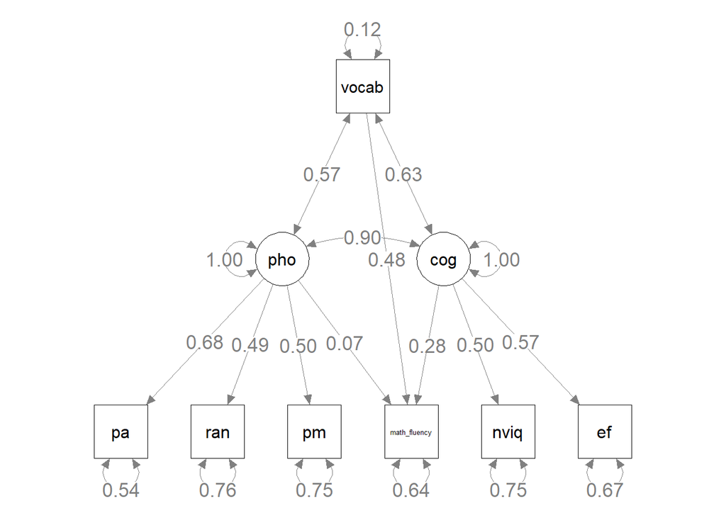

```r
plot(stage2)
```

Model fit statistic indicate a good fit, with Chi-square X2(9)=33.5944, p<.001, CFI = 0.9872, RMSEA = 0.0127 pho –> math fluency was not significant cog –> math fluency was not significant vocab –> math fluency was not significant